# Inflation and Real Wage Growth in the United States

**Question:** How has inflation affected real wage growth in the United States over the last 20 years?

**Expectation (from the plan):** Periods of higher inflation should go with lower real wage growth. When prices rise faster than wages, workers lose purchasing power. The expectation is supported if the regression of real wage growth on inflation has a negative slope. It is contradicted if the slope is positive or close to zero.

Real wage growth is roughly nominal wage growth minus inflation, so part of that negative slope is built in by definition. Step 7 therefore also regresses *nominal* wage growth on inflation. A slope below 1 there means wages do not keep up with prices, which is the real test of the expectation.

```python
import numpy as np
import pandas as pd
import matplotlib.pyplot as plt
```

## Step 1: Connect to FRED

The data comes straight from the FRED API through `fredapi`. The API key is stored in a `.env` file as `FRED_API_KEY`. `python-dotenv` loads it into the environment. The key is passed to the API client and is never printed.

```python
import os

from dotenv import load_dotenv
from fredapi import Fred

load_dotenv()
if "FRED_API_KEY" not in os.environ:
    raise RuntimeError("FRED_API_KEY is missing. Add it to a .env file in this folder.")
fred = Fred(api_key=os.environ["FRED_API_KEY"])
```

## Step 2: Download the data

Both series are monthly and seasonally adjusted:

| FRED ID | Series | Units | Used for |
| --- | --- | --- | --- |
| `CPIAUCSL` | Consumer Price Index for All Urban Consumers | Index, 1982–84 = 100 | Inflation |
| `CES0500000003` | Average Hourly Earnings of All Employees, Total Private | Dollars per hour | Wages |

`fetch_series` downloads one series and gives it a readable name. Both series are joined on date and only months that have both values are kept.

```python
SERIES_IDS = {"cpi": "CPIAUCSL", "hourly_wage": "CES0500000003"}
DATA_SOURCE = "Source: FRED, Federal Reserve Bank of St. Louis (CPIAUCSL, CES0500000003)"


def fetch_series(name, series_id):
    """Download one FRED series as a monthly pandas Series called `name`."""
    return fred.get_series(series_id).rename(name)


raw_data = pd.concat(
    [fetch_series(name, series_id) for name, series_id in SERIES_IDS.items()],
    axis=1,
).dropna()
raw_data.tail()
```

|  | cpi | hourly_wage |
| --- | --- | --- |
| 2026-04-01 | 332.407 | 37.41 |
| 2026-05-01 | 333.979 | 37.49 |
| 2026-06-01 | 332.568 | 37.59 |
| 2026-07-01 | 332.813 | 37.64 |
| 2026-08-01 | 334.131 | 37.76 |

## Step 3: Clean the data and build the growth rates

1. **Real wage:** Divide the nominal hourly wage by CPI. Rescale so the result is in dollars at the most recent month's prices.
2. **Year-over-year growth:** Take the percent change from the same month one year earlier. Do this for CPI (inflation), nominal wages, and real wages. Comparing to the same month a year ago keeps seasonal patterns from distorting the result.
3. **Last 20 years:** Keep only the most recent 20 years. The earnings series starts in March 2006, and each growth rate needs 12 earlier months. So the sample actually starts in early 2007.

```python
YEARS_TO_KEEP = 20


def yoy_percent_change(series):
    """Percent change from the same month one year earlier."""
    return series.pct_change(12) * 100


def build_dataset(raw, years):
    """Add real wages and year-over-year growth rates, then keep the last `years` years."""
    data = raw.copy()
    data["real_wage"] = data["hourly_wage"] * data["cpi"].iloc[-1] / data["cpi"]
    data["inflation"] = yoy_percent_change(data["cpi"])
    data["nominal_wage_growth"] = yoy_percent_change(data["hourly_wage"])
    data["real_wage_growth"] = yoy_percent_change(data["real_wage"])
    data = data.dropna()
    start_date = data.index[-1] - pd.DateOffset(years=years)
    return data[data.index >= start_date]


wage_data = build_dataset(raw_data, YEARS_TO_KEEP)
print(f"Sample: {wage_data.index[0]:%b %Y} to {wage_data.index[-1]:%b %Y} ({len(wage_data)} months)")
wage_data[["inflation", "nominal_wage_growth", "real_wage_growth"]].describe().round(2)
```

```
Sample: Mar 2007 to Aug 2026 (233 months)
```

|  | inflation | nominal_wage_growth | real_wage_growth |
| --- | --- | --- | --- |
| count | 233.00 | 233.00 | 233.00 |
| mean | 2.56 | 3.17 | 0.62 |
| std | 1.94 | 1.15 | 1.66 |
| min | -1.96 | 0.60 | -3.39 |
| 25% | 1.49 | 2.16 | -0.28 |
| 50% | 2.21 | 2.94 | 0.63 |
| 75% | 3.25 | 3.97 | 1.38 |
| max | 8.98 | 8.10 | 7.76 |

## Step 4: Line chart of inflation and real wage growth over time

This chart puts both year-over-year rates on one axis. If the expectation is right, real wage growth should drop when inflation rises.

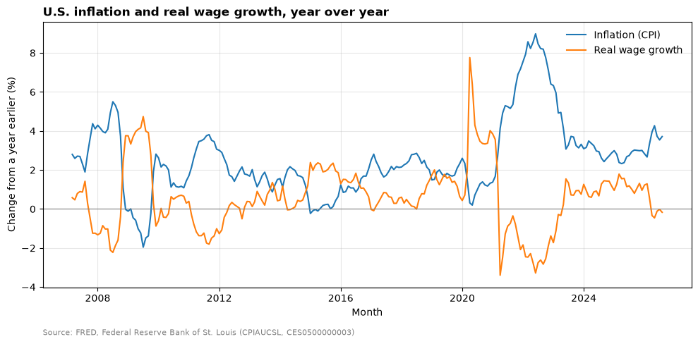

```python
def add_chart_labels(ax, title, xlabel, ylabel):
    """Add a title, axis labels, the data source note, and a zero line to a chart."""
    ax.set_title(title, loc="left", fontweight="bold")
    ax.set_xlabel(xlabel)
    ax.set_ylabel(ylabel)
    ax.axhline(0, color="gray", linewidth=0.8)
    ax.grid(alpha=0.3)
    ax.annotate(DATA_SOURCE, xy=(0, -0.18), xycoords="axes fraction", fontsize=8, color="gray")


fig, ax = plt.subplots(figsize=(10, 5))
ax.plot(wage_data.index, wage_data["inflation"], label="Inflation (CPI)")
ax.plot(wage_data.index, wage_data["real_wage_growth"], label="Real wage growth")
add_chart_labels(
    ax,
    title="U.S. inflation and real wage growth, year over year",
    xlabel="Month",
    ylabel="Change from a year earlier (%)",
)
ax.legend(frameon=False)
fig.tight_layout()
plt.show()
```

## Step 5: Regression of real wage growth on inflation

The model is a simple linear regression on monthly data:

$$\text{real wage growth} = a + b \times \text{inflation}$$

A negative slope $b$ supports the expectation. `fit_line` uses `np.polyfit` to estimate the intercept and slope, and reports R² as well. `regression_table` runs the fit twice, so the same check can be repeated for nominal wages in Step 7.

The second row is a robustness check that drops 2020–2021. In 2020 many low-wage workers lost their jobs, so *average* hourly earnings went up even though no individual got a raise. That spike could distort the fit.

```python
def fit_line(x, y):
    """Fit y = intercept + slope * x by least squares and return the results."""
    slope, intercept = np.polyfit(x, y, 1)
    r_squared = np.corrcoef(x, y)[0, 1] ** 2
    return {"slope": slope, "intercept": intercept, "r_squared": r_squared, "months": len(x)}


is_pandemic_period = (wage_data.index >= "2020-01-01") & (wage_data.index < "2022-01-01")
excl_pandemic = wage_data[~is_pandemic_period]


def regression_table(y_column):
    """Regress `y_column` on inflation for the full sample and excluding 2020-2021."""
    table = pd.DataFrame({
        "Full sample": fit_line(wage_data["inflation"], wage_data[y_column]),
        "Excluding 2020-2021": fit_line(excl_pandemic["inflation"], excl_pandemic[y_column]),
    }).T
    return table.astype({"months": int})


real_wage_results = regression_table("real_wage_growth")
real_wage_results.round(3)
```

|  | slope | intercept | r_squared | months |
| --- | --- | --- | --- | --- |
| Full sample | -0.685 | 2.370 | 0.642 | 233 |
| Excluding 2020-2021 | -0.631 | 2.091 | 0.724 | 209 |

## Step 6: Scatter plot with the fitted line

Each dot is one month. The line is the full-sample regression from Step 5. `plot_fit` draws the chart so it can be reused for nominal wages in Step 7.

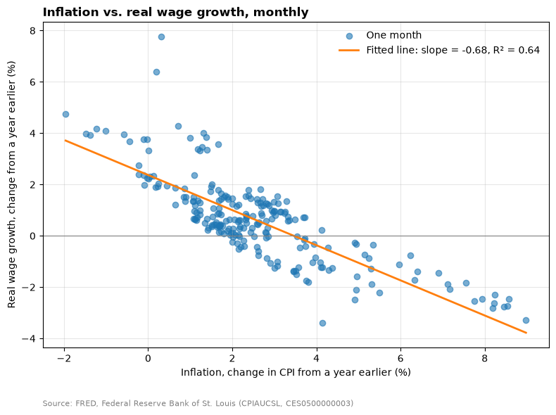

```python
def plot_fit(y_column, fit, title, ylabel):
    """Scatter `y_column` against inflation and draw the fitted regression line."""
    inflation_range = np.linspace(wage_data["inflation"].min(), wage_data["inflation"].max(), 100)
    fig, ax = plt.subplots(figsize=(8, 6))
    ax.scatter(wage_data["inflation"], wage_data[y_column], alpha=0.6, label="One month")
    ax.plot(
        inflation_range,
        fit["intercept"] + fit["slope"] * inflation_range,
        color="tab:orange",
        linewidth=2,
        label=f"Fitted line: slope = {fit['slope']:.2f}, R² = {fit['r_squared']:.2f}",
    )
    add_chart_labels(
        ax,
        title=title,
        xlabel="Inflation, change in CPI from a year earlier (%)",
        ylabel=ylabel,
    )
    ax.legend(frameon=False)
    fig.tight_layout()
    plt.show()


plot_fit(
    "real_wage_growth",
    real_wage_results.loc["Full sample"],
    title="Inflation vs. real wage growth, monthly",
    ylabel="Real wage growth, change from a year earlier (%)",
)
```

## Step 7: Is the negative slope built in? Nominal wage growth on inflation

Real wage growth is roughly nominal wage growth minus inflation. If nominal wages did not react to inflation at all, the Step 5 slope would be about −1 just from that definition. So the negative slope alone does not show much.

The better test regresses nominal wage growth on inflation:

$$\text{nominal wage growth} = a + c \times \text{inflation}$$

- $c = 1$: wages rise one-for-one with prices, and real wages are unaffected by inflation.
- $0 < c < 1$: wages rise with inflation, but not by enough, so real wages fall. This supports the expectation.
- $c \le 0$: wages do not respond to inflation at all.

The two regressions are linked: the real-wage slope is approximately $c - 1$. The last line of the output checks this.

```python
nominal_wage_results = regression_table("nominal_wage_growth")
nominal_slope = nominal_wage_results.loc["Full sample", "slope"]
real_slope = real_wage_results.loc["Full sample", "slope"]
print(f"Nominal slope - 1 = {nominal_slope - 1:.2f}, real-wage slope = {real_slope:.2f}")
nominal_wage_results.round(3)
```

```
Nominal slope - 1 = -0.71, real-wage slope = -0.68
```

|  | slope | intercept | r_squared | months |
| --- | --- | --- | --- | --- |
| Full sample | 0.295 | 2.413 | 0.247 | 233 |
| Excluding 2020-2021 | 0.348 | 2.132 | 0.440 | 209 |

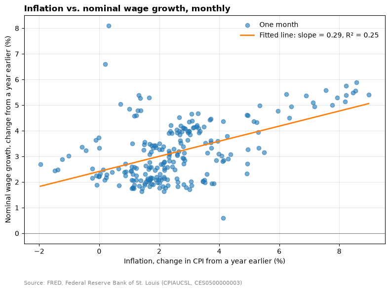

```python
plot_fit(
    "nominal_wage_growth",
    nominal_wage_results.loc["Full sample"],
    title="Inflation vs. nominal wage growth, monthly",
    ylabel="Nominal wage growth, change from a year earlier (%)",
)
```

## Step 8: Annual averages

Yearly averages of the monthly rates make each period easier to compare. Real wage growth is roughly nominal wage growth minus inflation. The current year covers only the months released so far.

```python
annual_averages = wage_data[["inflation", "nominal_wage_growth", "real_wage_growth"]].resample("YE").mean()
annual_averages.index = annual_averages.index.year
annual_averages.round(2)
```

|  | inflation | nominal_wage_growth | real_wage_growth |
| --- | --- | --- | --- |
| 2007 | 2.99 | 3.23 | 0.24 |
| 2008 | 3.83 | 3.15 | -0.63 |
| 2009 | -0.31 | 2.81 | 3.15 |
| 2010 | 1.64 | 1.84 | 0.20 |
| 2011 | 3.14 | 2.00 | -1.10 |
| 2012 | 2.08 | 1.90 | -0.17 |
| 2013 | 1.47 | 2.10 | 0.63 |
| 2014 | 1.62 | 2.08 | 0.46 |
| 2015 | 0.12 | 2.25 | 2.13 |
| 2016 | 1.27 | 2.57 | 1.28 |
| 2017 | 2.13 | 2.56 | 0.42 |
| 2018 | 2.44 | 3.01 | 0.56 |
| 2019 | 1.81 | 3.31 | 1.47 |
| 2020 | 1.25 | 4.86 | 3.57 |
| 2021 | 4.68 | 4.28 | -0.35 |
| 2022 | 8.00 | 5.38 | -2.42 |
| 2023 | 4.15 | 4.46 | 0.31 |
| 2024 | 2.95 | 4.04 | 1.06 |
| 2025 | 2.75 | 4.02 | 1.23 |
| 2026 | 3.50 | 3.76 | 0.25 |

## Conclusion

**The expectation is supported, but the evidence comes from the nominal wage regression.** In the data available when this was written (through August 2026), each extra percentage point of inflation matched about 0.7 percentage points less real wage growth (R² ≈ 0.64). Most of that slope is built in, because real wage growth is roughly nominal wage growth minus inflation.

**Limitations**

- **Correlation, not causation:** The models have no controls, such as unemployment, productivity, or energy prices, that could drive both variables.
- **Overlapping data:** Year-over-year rates from consecutive months share 11 months of data, so the monthly observations are not independent. That makes the fits look more precise than they are.
- **Wages adjust with a delay:** Wage contracts are often set once a year, so wages may catch up with inflation later. These regressions only compare the same month and miss any delayed catch-up.
- **Composition effects:** Average hourly earnings change when the mix of workers changes, as it did in 2020. The series also covers only private-sector employees.
- **Short history:** The earnings series starts in 2006, so the 20 years include just a few inflation episodes.